# candidate_genes_discovery

lihui xiang

2025-04-02

#### I. Literature Reference

**Otero et al. (2024)** – [Evaluation of the Genetic Diversity, Haplotype, and Virulence of *Fusarium oxysporum* f. sp. *vasinfectum* Field Isolates from Alabama](https://apsjournals.apsnet.org/doi/10.1094/PHYTO-11-23-0438-R)

This study revealed that the race 4 isolate 89-1A carries a set of small accessory chromosomes, including those harboring lactamase-related genes. These accessory chromosomes are postulated to contribute to the virulence of *Fusarium oxysporum* f. sp. *vasinfectum* on cotton, suggesting a potential role of horizontally transferred elements in pathogenicity.

#### II.conclusion from the reference

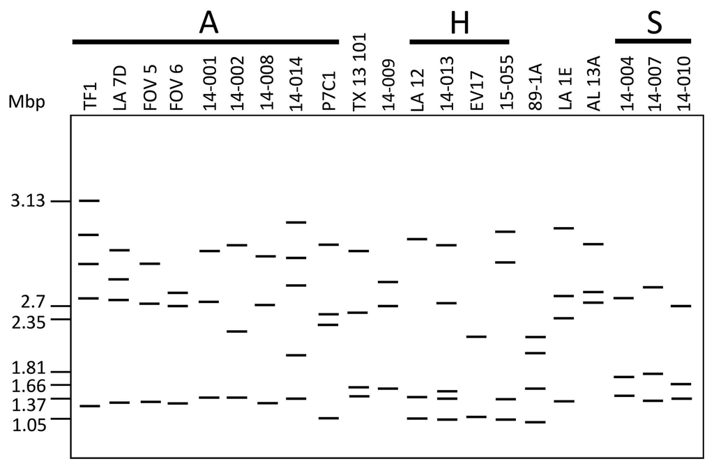

**Figure 2. Small Chromosome Diversity in Fov Isolates. (Otero et al. 2024)**

The race 4 isolate **89-1A** shows distinct small chromosome bands compared to other isolates. These unique chromosomes are likely accessory chromosomes and may contain virulence-associated genes, such as lactamases, contributing to increased pathogenicity on cotton.